# 상품군별 온라인쇼핑 해외직접판매액 분석

[통계청 KOSIS] | 도소매 서비스 | 온라인쇼핑동향조사 | 지역별 / 상품군별 온라인쇼핑 해외직접판매액

(https://kosis.kr/statHtml/statHtml.do?orgId=101&tblId=DT_1KE10081&vw_cd=MT_ZTITLE&list_id=JF&seqNo=&lang_mode=ko&language=kor&obj_var_id=&itm_id=&conn_path=MT_ZTITLE)

#### 1. 주제

지역별/상품군별 온라인쇼핑 해외직접판매액 최근 5년간 데이터 분석

#### 2. 동기

통계청 온라인쇼핑동향조사를 통해 지역별/상품군별 온라인쇼핑 해외직접판매액의 변화를 파악하고, 이를 바탕으로 국내 온라인쇼핑 산업의 발전 방향을 모색하고자 함

#### 3. 성찰

데이터 분석을 통해 지역별/상품군별 온라인쇼핑 해외직접판매액의 변화를 파악하고, 이를 바탕으로 국내 온라인쇼핑 산업의 발전 방향을 모색할 수 있었음. 데이터 분석 과정에서 다양한 통계적 기법을 활용하여 데이터를 분석하고, 이를 시각화하는 능력을 향상시킬 수 있었음

#### 4. 참고 문헌

네이버 부스트코스 <파이썬으로 시작하는 데이터 사이언스> (https://www.boostcourse.org/ds112/lecture/59899)

#### 5. 데이터 설명

각 행은 특정 지역, 상품군, 판매 유형 및 기간에 대한 판매 데이터를 나타낸다. 각 열은 데이터의 속성을 나타내며, 다양한 수준의 지역, 상품군, 판매 유형 및 판매 금액을 포함한다.

- 지역별(1): 대륙 또는 국가 수준의 분류.
- 지역별(2): 더 세부적인 지역 수준의 분류.
- 지역별(3): 가장 세부적인 지역 수준의 분류.
- 상품군별(1): 대분류 상품군.
- 상품군별(2): 소분류 상품군.
- 판매유형별(1): 판매 유형을 나타내는 열로, '계', '면세점', '면세점 이외'와 같은 값을 가짐.
- 기간: 각 기간을 나타내는 열로, 분기별 데이터를 포함. 예를 들어, '2020.1/4'는 2020년 1분기를 의미.
- 백만원: 해당 기간 동안의 판매 금액을 백만원 단위로 나타내는 열. (판매 성과를 나타내는 종속변수)

#### 6~7. 데이터 분석 및 시각화

```python
import pandas as pd
import numpy as np
import seaborn as sns
import matplotlib.pyplot as plt
```

```python
df = pd.read_csv("data.csv", encoding="cp949")
df.head()
```

|  | 지역별(1) | 지역별(2) | 지역별(3) | 상품군별(1) | 상품군별(2) | 판매유형별(1) | 2020.1/4 | 2020.2/4 | 2020.3/4 | 2020.4/4 | ... | 2021.4/4 | 2022.1/4 | 2022.2/4 | 2022.3/4 | 2022.4/4 | 2023.1/4 | 2023.2/4 | 2023.3/4 | 2023.4/4 | 2024.1/4 p) |
| --- | --- | --- | --- | --- | --- | --- | --- | --- | --- | --- | --- | --- | --- | --- | --- | --- | --- | --- | --- | --- | --- |
| 0 | 합계 | 소계 | 소계 | 합계 | 소계 | 계 | 1531212 | 1290332 | 1656729 | 1525174 | ... | 932840 | 575319 | 505011 | 421606 | 353963 | 291336 | 481202 | 452744 | 471927 | 399086 |
| 1 | 합계 | 소계 | 소계 | 합계 | 소계 | 면세점 | 1297490 | 1051987 | 1410967 | 1247495 | ... | 681168 | 363520 | 300602 | 211727 | 152997 | 111187 | 281235 | 271525 | 280391 | 239885 |
| 2 | 합계 | 소계 | 소계 | 합계 | 소계 | 면세점 이외 | 233722 | 238345 | 245762 | 277679 | ... | 251672 | 211799 | 204409 | 209879 | 200966 | 180149 | 199967 | 181219 | 191536 | 159201 |
| 3 | 합계 | 소계 | 소계 | 컴퓨터 및 주변기기 | 소계 | 계 | 4142 | 3814 | 7722 | 3589 | ... | 3174 | 2943 | 3288 | 2944 | 3195 | 4044 | 3205 | 4260 | 3769 | 2729 |
| 4 | 합계 | 소계 | 소계 | 컴퓨터 및 주변기기 | 소계 | 면세점 | 113 | 0 | 3497 | 0 | ... | 0 | 0 | 0 | 0 | 0 | 0 | 0 | 0 | 0 | 0 |

5 rows × 23 columns

data.csv를 불러온다.

```python
df_melted = df.melt(id_vars=['지역별(1)', '지역별(2)', '지역별(3)', '상품군별(1)', '상품군별(2)', '판매유형별(1)'],
                    var_name='기간', value_name="백만원")
df_melted
```

|  | 지역별(1) | 지역별(2) | 지역별(3) | 상품군별(1) | 상품군별(2) | 판매유형별(1) | 기간 | 백만원 |
| --- | --- | --- | --- | --- | --- | --- | --- | --- |
| 0 | 합계 | 소계 | 소계 | 합계 | 소계 | 계 | 2020.1/4 | 1531212 |
| 1 | 합계 | 소계 | 소계 | 합계 | 소계 | 면세점 | 2020.1/4 | 1297490 |
| 2 | 합계 | 소계 | 소계 | 합계 | 소계 | 면세점 이외 | 2020.1/4 | 233722 |
| 3 | 합계 | 소계 | 소계 | 컴퓨터 및 주변기기 | 소계 | 계 | 2020.1/4 | 4142 |
| 4 | 합계 | 소계 | 소계 | 컴퓨터 및 주변기기 | 소계 | 면세점 | 2020.1/4 | 113 |
| ... | ... | ... | ... | ... | ... | ... | ... | ... |
| 16468 | 기타 | 소계 | 소계 | 생활·자동차용품 | 소계 | 면세점 | 2024.1/4 p) | - |
| 16469 | 기타 | 소계 | 소계 | 생활·자동차용품 | 소계 | 면세점 이외 | 2024.1/4 p) | - |
| 16470 | 기타 | 소계 | 소계 | 기 타 | 소계 | 계 | 2024.1/4 p) | - |
| 16471 | 기타 | 소계 | 소계 | 기 타 | 소계 | 면세점 | 2024.1/4 p) | - |
| 16472 | 기타 | 소계 | 소계 | 기 타 | 소계 | 면세점 이외 | 2024.1/4 p) | - |

16473 rows × 8 columns

데이터를 보면 컬럼이 2014.1/4 형식처럼 분기별로 되어있는 것을 볼 수 있다.

그렇기 때문에, melt 함수를 이용하여 예쁘게 정리되도록 하였다.

```python
df_melted.shape
```

```
(16473, 8)
```

```python
df_melted.info()
```

```
<class 'pandas.core.frame.DataFrame'>
RangeIndex: 16473 entries, 0 to 16472
Data columns (total 8 columns):
 #   Column    Non-Null Count  Dtype
---  ------    --------------  -----
 0   지역별(1)    16473 non-null  object
 1   지역별(2)    16473 non-null  object
 2   지역별(3)    16473 non-null  object
 3   상품군별(1)   16473 non-null  object
 4   상품군별(2)   16473 non-null  object
 5   판매유형별(1)  16473 non-null  object
 6   기간        16473 non-null  object
 7   백만원       16473 non-null  object
dtypes: object(8)
memory usage: 1.0+ MB
```

데이터 정보를 보면 각 컬럼당 16473개의 데이터가 수록되어 있다.

```python
df_melted['기간']
```

```
0           2020.1/4
1           2020.1/4
2           2020.1/4
3           2020.1/4
4           2020.1/4
            ...
16468    2024.1/4 p)
16469    2024.1/4 p)
16470    2024.1/4 p)
16471    2024.1/4 p)
16472    2024.1/4 p)
Name: 기간, Length: 16473, dtype: object
```

그런데 '기간' 데이터를 보면 '년도.분기/4 p' 이런 형태로 되어 있는 것을 볼 수 있다.

```python
df_melted['연도'] = df_melted['기간'].map(lambda x:int(x.split('.')[0]))
df_melted
```

|  | 지역별(1) | 지역별(2) | 지역별(3) | 상품군별(1) | 상품군별(2) | 판매유형별(1) | 기간 | 백만원 | 연도 |
| --- | --- | --- | --- | --- | --- | --- | --- | --- | --- |
| 0 | 합계 | 소계 | 소계 | 합계 | 소계 | 계 | 2020.1/4 | 1531212 | 2020 |
| 1 | 합계 | 소계 | 소계 | 합계 | 소계 | 면세점 | 2020.1/4 | 1297490 | 2020 |
| 2 | 합계 | 소계 | 소계 | 합계 | 소계 | 면세점 이외 | 2020.1/4 | 233722 | 2020 |
| 3 | 합계 | 소계 | 소계 | 컴퓨터 및 주변기기 | 소계 | 계 | 2020.1/4 | 4142 | 2020 |
| 4 | 합계 | 소계 | 소계 | 컴퓨터 및 주변기기 | 소계 | 면세점 | 2020.1/4 | 113 | 2020 |
| ... | ... | ... | ... | ... | ... | ... | ... | ... | ... |
| 16468 | 기타 | 소계 | 소계 | 생활·자동차용품 | 소계 | 면세점 | 2024.1/4 p) | - | 2024 |
| 16469 | 기타 | 소계 | 소계 | 생활·자동차용품 | 소계 | 면세점 이외 | 2024.1/4 p) | - | 2024 |
| 16470 | 기타 | 소계 | 소계 | 기 타 | 소계 | 계 | 2024.1/4 p) | - | 2024 |
| 16471 | 기타 | 소계 | 소계 | 기 타 | 소계 | 면세점 | 2024.1/4 p) | - | 2024 |
| 16472 | 기타 | 소계 | 소계 | 기 타 | 소계 | 면세점 이외 | 2024.1/4 p) | - | 2024 |

16473 rows × 9 columns

map 함수와 lambda 함수를 이용하여

'기간'의 str 값을 split으로 쪼개어 연도만 선택한 값을 '연도' 칼럼으로 따로 만들었다.

```python
df_melted['분기'] = df_melted['기간'].map(lambda x:int(x.split('.')[1].split('/')[0]))
df_melted
```

|  | 지역별(1) | 지역별(2) | 지역별(3) | 상품군별(1) | 상품군별(2) | 판매유형별(1) | 기간 | 백만원 | 연도 | 분기 |
| --- | --- | --- | --- | --- | --- | --- | --- | --- | --- | --- |
| 0 | 합계 | 소계 | 소계 | 합계 | 소계 | 계 | 2020.1/4 | 1531212 | 2020 | 1 |
| 1 | 합계 | 소계 | 소계 | 합계 | 소계 | 면세점 | 2020.1/4 | 1297490 | 2020 | 1 |
| 2 | 합계 | 소계 | 소계 | 합계 | 소계 | 면세점 이외 | 2020.1/4 | 233722 | 2020 | 1 |
| 3 | 합계 | 소계 | 소계 | 컴퓨터 및 주변기기 | 소계 | 계 | 2020.1/4 | 4142 | 2020 | 1 |
| 4 | 합계 | 소계 | 소계 | 컴퓨터 및 주변기기 | 소계 | 면세점 | 2020.1/4 | 113 | 2020 | 1 |
| ... | ... | ... | ... | ... | ... | ... | ... | ... | ... | ... |
| 16468 | 기타 | 소계 | 소계 | 생활·자동차용품 | 소계 | 면세점 | 2024.1/4 p) | - | 2024 | 1 |
| 16469 | 기타 | 소계 | 소계 | 생활·자동차용품 | 소계 | 면세점 이외 | 2024.1/4 p) | - | 2024 | 1 |
| 16470 | 기타 | 소계 | 소계 | 기 타 | 소계 | 계 | 2024.1/4 p) | - | 2024 | 1 |
| 16471 | 기타 | 소계 | 소계 | 기 타 | 소계 | 면세점 | 2024.1/4 p) | - | 2024 | 1 |
| 16472 | 기타 | 소계 | 소계 | 기 타 | 소계 | 면세점 이외 | 2024.1/4 p) | - | 2024 | 1 |

16473 rows × 10 columns

추가로, '/'로 짤라내서 분기 부분만 추출하여 '분기' 칼럼으로 따로 만들어줬다.

```python
df_melted['기간'] = df_melted['연도'].astype(str) + '/' + df_melted['분기'].astype(str)
df_melted
```

|  | 지역별(1) | 지역별(2) | 지역별(3) | 상품군별(1) | 상품군별(2) | 판매유형별(1) | 기간 | 백만원 | 연도 | 분기 |
| --- | --- | --- | --- | --- | --- | --- | --- | --- | --- | --- |
| 0 | 합계 | 소계 | 소계 | 합계 | 소계 | 계 | 2020/1 | 1531212 | 2020 | 1 |
| 1 | 합계 | 소계 | 소계 | 합계 | 소계 | 면세점 | 2020/1 | 1297490 | 2020 | 1 |
| 2 | 합계 | 소계 | 소계 | 합계 | 소계 | 면세점 이외 | 2020/1 | 233722 | 2020 | 1 |
| 3 | 합계 | 소계 | 소계 | 컴퓨터 및 주변기기 | 소계 | 계 | 2020/1 | 4142 | 2020 | 1 |
| 4 | 합계 | 소계 | 소계 | 컴퓨터 및 주변기기 | 소계 | 면세점 | 2020/1 | 113 | 2020 | 1 |
| ... | ... | ... | ... | ... | ... | ... | ... | ... | ... | ... |
| 16468 | 기타 | 소계 | 소계 | 생활·자동차용품 | 소계 | 면세점 | 2024/1 | - | 2024 | 1 |
| 16469 | 기타 | 소계 | 소계 | 생활·자동차용품 | 소계 | 면세점 이외 | 2024/1 | - | 2024 | 1 |
| 16470 | 기타 | 소계 | 소계 | 기 타 | 소계 | 계 | 2024/1 | - | 2024 | 1 |
| 16471 | 기타 | 소계 | 소계 | 기 타 | 소계 | 면세점 | 2024/1 | - | 2024 | 1 |
| 16472 | 기타 | 소계 | 소계 | 기 타 | 소계 | 면세점 이외 | 2024/1 | - | 2024 | 1 |

16473 rows × 10 columns

그리고 기간과 분기를 이용하여 '기간' 컬럼을 새롭게 정의해주었다.

```python
df_melted['백만원'] = df_melted['백만원'].replace('-', np.nan).astype(float)
df_melted
```

|  | 지역별(1) | 지역별(2) | 지역별(3) | 상품군별(1) | 상품군별(2) | 판매유형별(1) | 기간 | 백만원 | 연도 | 분기 |
| --- | --- | --- | --- | --- | --- | --- | --- | --- | --- | --- |
| 0 | 합계 | 소계 | 소계 | 합계 | 소계 | 계 | 2020/1 | 1531212.0 | 2020 | 1 |
| 1 | 합계 | 소계 | 소계 | 합계 | 소계 | 면세점 | 2020/1 | 1297490.0 | 2020 | 1 |
| 2 | 합계 | 소계 | 소계 | 합계 | 소계 | 면세점 이외 | 2020/1 | 233722.0 | 2020 | 1 |
| 3 | 합계 | 소계 | 소계 | 컴퓨터 및 주변기기 | 소계 | 계 | 2020/1 | 4142.0 | 2020 | 1 |
| 4 | 합계 | 소계 | 소계 | 컴퓨터 및 주변기기 | 소계 | 면세점 | 2020/1 | 113.0 | 2020 | 1 |
| ... | ... | ... | ... | ... | ... | ... | ... | ... | ... | ... |
| 16468 | 기타 | 소계 | 소계 | 생활·자동차용품 | 소계 | 면세점 | 2024/1 | NaN | 2024 | 1 |
| 16469 | 기타 | 소계 | 소계 | 생활·자동차용품 | 소계 | 면세점 이외 | 2024/1 | NaN | 2024 | 1 |
| 16470 | 기타 | 소계 | 소계 | 기 타 | 소계 | 계 | 2024/1 | NaN | 2024 | 1 |
| 16471 | 기타 | 소계 | 소계 | 기 타 | 소계 | 면세점 | 2024/1 | NaN | 2024 | 1 |
| 16472 | 기타 | 소계 | 소계 | 기 타 | 소계 | 면세점 이외 | 2024/1 | NaN | 2024 | 1 |

16473 rows × 10 columns

'백만원' 컬럼에 - 와 같이 미기입된 데이터가 있으므로,

pd.np.nan으로 NaN 데이터로 변경해주고, float 형식으로 지정하였다.

```python
df_melted2 = df_melted[(df_melted['지역별(1)']!='합계')&(df_melted['지역별(2)']!='소계')&(df_melted['상품군별(1)']!='합계')]
df_melted2
```

|  | 지역별(1) | 지역별(2) | 지역별(3) | 상품군별(1) | 상품군별(2) | 판매유형별(1) | 기간 | 백만원 | 연도 | 분기 |
| --- | --- | --- | --- | --- | --- | --- | --- | --- | --- | --- |
| 105 | 아시아 | 중국 | 소계 | 컴퓨터 및 주변기기 | 소계 | 계 | 2020/1 | 61.0 | 2020 | 1 |
| 106 | 아시아 | 중국 | 소계 | 컴퓨터 및 주변기기 | 소계 | 면세점 | 2020/1 | 0.0 | 2020 | 1 |
| 107 | 아시아 | 중국 | 소계 | 컴퓨터 및 주변기기 | 소계 | 면세점 이외 | 2020/1 | 61.0 | 2020 | 1 |
| 108 | 아시아 | 중국 | 소계 | 가전·전자·통신기기 | 소계 | 계 | 2020/1 | 3096.0 | 2020 | 1 |
| 109 | 아시아 | 중국 | 소계 | 가전·전자·통신기기 | 소계 | 면세점 | 2020/1 | 2653.0 | 2020 | 1 |
| ... | ... | ... | ... | ... | ... | ... | ... | ... | ... | ... |
| 16264 | 유럽 | 기타 유럽 | 소계 | 생활·자동차용품 | 소계 | 면세점 | 2024/1 | 0.0 | 2024 | 1 |
| 16265 | 유럽 | 기타 유럽 | 소계 | 생활·자동차용품 | 소계 | 면세점 이외 | 2024/1 | 68.0 | 2024 | 1 |
| 16266 | 유럽 | 기타 유럽 | 소계 | 기 타 | 소계 | 계 | 2024/1 | 6.0 | 2024 | 1 |
| 16267 | 유럽 | 기타 유럽 | 소계 | 기 타 | 소계 | 면세점 | 2024/1 | 0.0 | 2024 | 1 |
| 16268 | 유럽 | 기타 유럽 | 소계 | 기 타 | 소계 | 면세점 이외 | 2024/1 | 6.0 | 2024 | 1 |

8976 rows × 10 columns

데이터 내 '합계'인 데이터를 제외하였다.

```python
df_melted2.info()
```

```
<class 'pandas.core.frame.DataFrame'>
Index: 8976 entries, 105 to 16268
Data columns (total 10 columns):
 #   Column    Non-Null Count  Dtype
---  ------    --------------  -----
 0   지역별(1)    8976 non-null   object
 1   지역별(2)    8976 non-null   object
 2   지역별(3)    8976 non-null   object
 3   상품군별(1)   8976 non-null   object
 4   상품군별(2)   8976 non-null   object
 5   판매유형별(1)  8976 non-null   object
 6   기간        8976 non-null   object
 7   백만원       5664 non-null   float64
 8   연도        8976 non-null   int64
 9   분기        8976 non-null   int64
dtypes: float64(1), int64(2), object(7)
memory usage: 771.4+ KB
```

```python
df_melted2.isnull().sum()
df_melted2.head()
```

|  | 지역별(1) | 지역별(2) | 지역별(3) | 상품군별(1) | 상품군별(2) | 판매유형별(1) | 기간 | 백만원 | 연도 | 분기 |
| --- | --- | --- | --- | --- | --- | --- | --- | --- | --- | --- |
| 105 | 아시아 | 중국 | 소계 | 컴퓨터 및 주변기기 | 소계 | 계 | 2020/1 | 61.0 | 2020 | 1 |
| 106 | 아시아 | 중국 | 소계 | 컴퓨터 및 주변기기 | 소계 | 면세점 | 2020/1 | 0.0 | 2020 | 1 |
| 107 | 아시아 | 중국 | 소계 | 컴퓨터 및 주변기기 | 소계 | 면세점 이외 | 2020/1 | 61.0 | 2020 | 1 |
| 108 | 아시아 | 중국 | 소계 | 가전·전자·통신기기 | 소계 | 계 | 2020/1 | 3096.0 | 2020 | 1 |
| 109 | 아시아 | 중국 | 소계 | 가전·전자·통신기기 | 소계 | 면세점 | 2020/1 | 2653.0 | 2020 | 1 |

```python
df_tot = df_melted2[df_melted2['판매유형별(1)'] == '계'].copy()
```

데이터 중 '판매유형별' 값이 '계'인 데이터만 복사하여 df_tot로 저장하였다.

[output not shown]

[output cut: 201 more lines]

[output not shown]

[figure not shown]

```python
sns.lineplot(data=df_tot, x='연도', y='백만원', hue='상품군별(1)')
plt.legend(bbox_to_anchor=(1.05, 1), loc=2, borderaxespad=0)
```

df_tot 데이터를 연도-백만원 그래프로 상품군별로 시각화하였다.

가장 큰 판매액은 '화장품' 상품인 것을 한 눈에 볼 수 있었다.

```python
df_sub = df_tot[~df_tot['상품군별(1)'].isin(['화장품'])].copy()
```

화장품 상품군이 압도적으로 많기 때문에 '화장품'을 제외한 데이터만 카피하여 df_sub에 저장하였다.

[output not shown]

[output cut: 191 more lines]

[output not shown]

[output not shown]

[output cut: 201 more lines]

[output not shown]

[figure not shown]

```python
sns.relplot(data=df_sub, x='연도', y='백만원', hue='상품군별(1)', kind='line', col='상품군별(1)', col_wrap=4)
```

화장품을 제외한 나머지 상품들(df_sub)을 시각화하였다.

[output not shown]

[output cut: 127 more lines]

[output not shown]

[output not shown]

[output cut: 137 more lines]

[output not shown]

[figure not shown]

```python
df_sub2 = df_tot[~df_tot['상품군별(1)'].isin(['화장품', '의류 및 패션 관련 상품', '음반·비디오·악기', '기 타', '가전·전자·통신기기'])].copy()
sns.relplot(data=df_sub2, x='연도', y='백만원', hue='상품군별(1)', kind='line', col='상품군별(1)', col_wrap=4)
```

앞선 그래프에서 '화장품' 상품 뿐만 아니라, '의류 및 패션 관련상품', '음반·비디오·악기', '가전·전자·통신기기', '기타' 항목도 큰 격차를 보이기 때문에 다시 한 번 sub로 지정하고 나머지 항목들을 시각화 해보았다.

[output not shown]

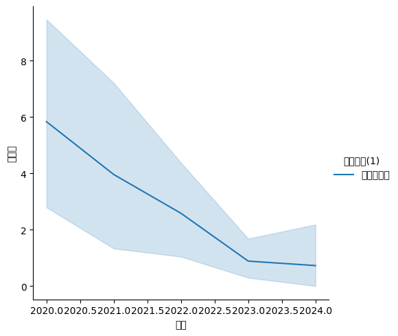

```python
sns.relplot(data=df_tot[df_tot['상품군별(1)']=='농축수산물'], x='연도', y='백만원', hue='상품군별(1)', kind='line')
```

그럼에도 불구하고, 평균 범위 내 표현이 잘 안 되는 '농축수산물'에 대해선 따로 시각화를 수행하였다.

```python
df_cos = df_tot[df_tot['상품군별(1)']=='화장품'].copy()
df_cos
```

|  | 지역별(1) | 지역별(2) | 지역별(3) | 상품군별(1) | 상품군별(2) | 판매유형별(1) | 기간 | 백만원 | 연도 | 분기 |
| --- | --- | --- | --- | --- | --- | --- | --- | --- | --- | --- |
| 135 | 아시아 | 중국 | 소계 | 화장품 | 소계 | 계 | 2020/1 | 1238820.0 | 2020 | 1 |
| 186 | 아시아 | 일본 | 소계 | 화장품 | 소계 | 계 | 2020/1 | 8154.0 | 2020 | 1 |
| 237 | 아시아 | 아세안 | 소계 | 화장품 | 소계 | 계 | 2020/1 | 25772.0 | 2020 | 1 |
| 288 | 아시아 | 중동 | 소계 | 화장품 | 소계 | 계 | 2020/1 | 671.0 | 2020 | 1 |
| 339 | 아시아 | 기타 아시아 | 소계 | 화장품 | 소계 | 계 | 2020/1 | NaN | 2020 | 1 |
| ... | ... | ... | ... | ... | ... | ... | ... | ... | ... | ... |
| 15996 | 북미 | 캐나다 | 소계 | 화장품 | 소계 | 계 | 2024/1 | 880.0 | 2024 | 1 |
| 16098 | 유럽 | 유럽연합+영국 | 소계 | 화장품 | 소계 | 계 | 2024/1 | 845.0 | 2024 | 1 |
| 16149 | 유럽 | 유럽연합+영국 | 유럽연합 | 화장품 | 소계 | 계 | 2024/1 | 718.0 | 2024 | 1 |
| 16200 | 유럽 | 유럽연합+영국 | 영국 | 화장품 | 소계 | 계 | 2024/1 | 127.0 | 2024 | 1 |
| 16251 | 유럽 | 기타 유럽 | 소계 | 화장품 | 소계 | 계 | 2024/1 | 190.0 | 2024 | 1 |

187 rows × 10 columns

이번엔 방금 전 가장 큰 판매액을 달성한 '화장품' 상품에 대해 분석해보겠다.

df_tot 데이터 중 상품군별이 '화장품'인 데이터만 따로 뺴낸 df_cos 데이터로 저장하였다.

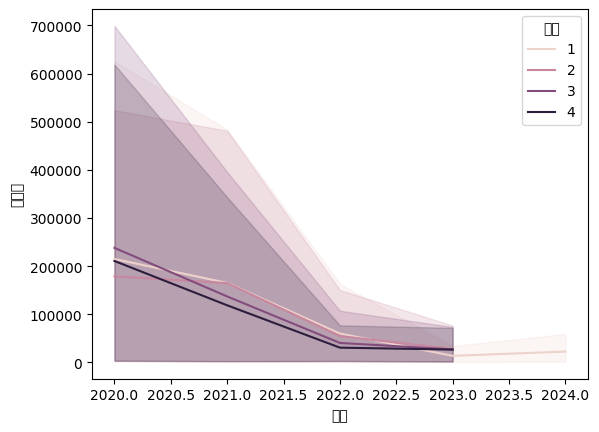

```python
sns.lineplot(data=df_cos, x="연도", y="백만원", hue="분기")
plt.figure(figsize=(15, 4))
```

df_cos 데이터를 연도-백만원 그래프로 분기별로 시각화하였다.

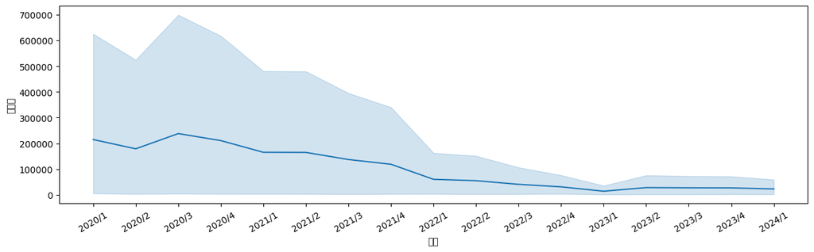

```python
plt.figure(figsize=(15,4))
plt.xticks(rotation=30)
sns.lineplot(data=df_cos, x='기간', y="백만원")
```

이번엔 분기가 포함된 기간-백만원 그래프로 표현하였다.

[output not shown]

[output cut: 53 more lines]

[output not shown]

[figure not shown]

```python
plt.figure(figsize=(15,4))
plt.xticks(rotation=30)
sns.lineplot(data=df_cos, x='기간', y="백만원", hue='지역별(2)')
```

기간-백만원 그래프를 국가별로 나타내었다.

중국이 압도적으로 많은 것을 볼 수 있다.

[output not shown]

[output cut: 53 more lines]

[output not shown]

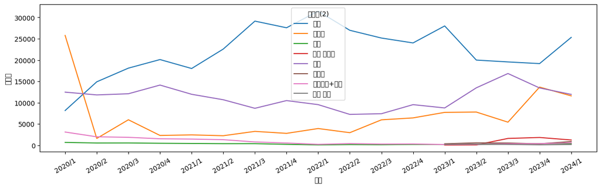

```python
df_csub = df_cos[~df_cos['지역별(2)'].isin(['중국'])].copy()
plt.figure(figsize=(15,4))
plt.xticks(rotation=30)
sns.lineplot(data=df_csub, x='기간', y="백만원", hue='지역별(2)')
```

좀 더 세분화된 분석을 위해 중국을 제외한 나머지 데이터를 시각화해보았다.

```
[Text(0.5, 1.0, '면세점 이외')]
```

[output not shown]

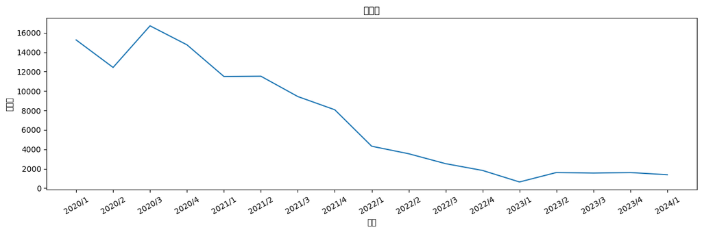

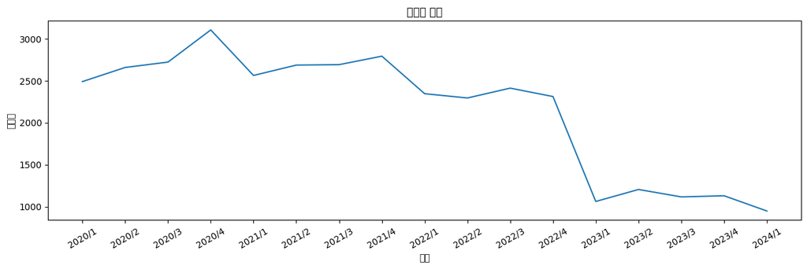

```python
plt.figure(figsize=(15,4))
plt.xticks(rotation=30)
sns.lineplot(data=df_melted2[df_melted2['판매유형별(1)']=='면세점'], x='기간', y="백만원", ci=None).set(title='면세점')

plt.figure(figsize=(15,4))
plt.xticks(rotation=30)
sns.lineplot(data=df_melted2[df_melted2['판매유형별(1)']=='면세점 이외'], x='기간', y="백만원", ci=None).set(title='면세점 이외')
```

[output not shown]

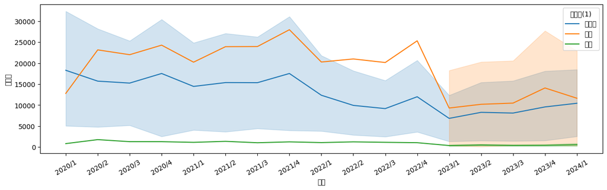

```python
df_fa = df_melted2[(df_melted2['상품군별(1)'] == '의류 및 패션 관련 상품') & (df_melted2['판매유형별(1)']=='계')].copy()
plt.figure(figsize=(15,4))
plt.xticks(rotation=30)
sns.lineplot(data=df_fa, x='기간', y="백만원", hue='지역별(1)')
```

다음은 의류 및 패션 관련 상품에 대해

```python
res = df_fa.pivot_table(index='지역별(2)', columns='연도', values='백만원', aggfunc='sum')
res
```

| 연도 지역별(2) | 2020 | 2021 | 2022 | 2023 | 2024 |
| --- | --- | --- | --- | --- | --- |
| 기타 아시아 | 0.0 | 0.0 | 0.0 | 672.0 | 159.0 |
| 기타 유럽 | 0.0 | 0.0 | 0.0 | 605.0 | 34.0 |
| 미국 | 82207.0 | 96044.0 | 86694.0 | 86764.0 | 22905.0 |
| 아세안 | 39339.0 | 30744.0 | 32980.0 | 27025.0 | 13506.0 |
| 유럽연합+영국 | 5128.0 | 4716.0 | 4442.0 | 5848.0 | 2132.0 |
| 일본 | 119531.0 | 116543.0 | 90984.0 | 55376.0 | 12176.0 |
| 중국 | 106346.0 | 101932.0 | 48969.0 | 80307.0 | 26216.0 |
| 중동 | 1776.0 | 1383.0 | 669.0 | 319.0 | 81.0 |
| 캐나다 | 0.0 | 0.0 | 0.0 | 1271.0 | 341.0 |

국가별-연도별로 판매액 합산값을 pivot table로 만들었다.

[output not shown]

[output not shown]

[output cut: 41 more lines]

[output not shown]

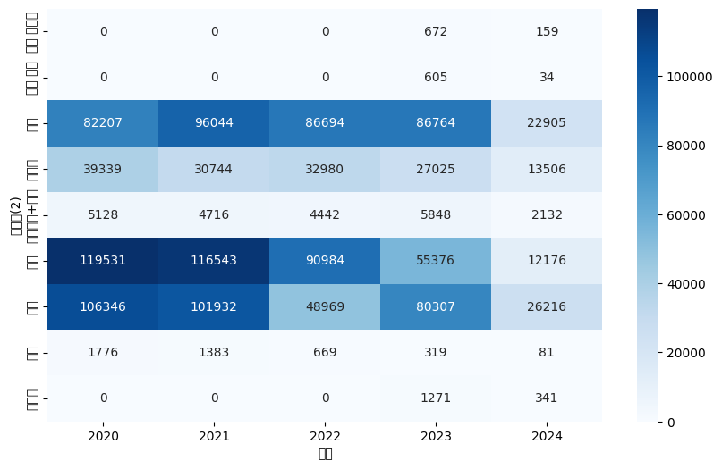

```python
plt.figure(figsize=(10, 6))
sns.heatmap(res, cmap='Blues', annot=True, fmt='.0f')
```

이를 heatmap으로 구현하였다.

중국, 일본, 미국의 판매액이 두드러지게 나타난 것을 볼 수 있다.

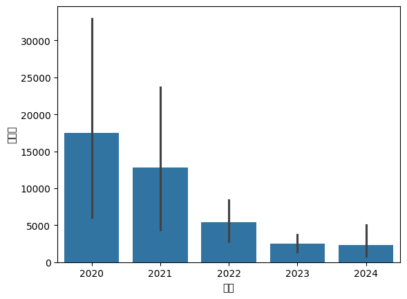

```python
sns.barplot(data=df_tot, x='연도', y='백만원')
```

df_tot 데이터를 이용하여 barplot으로 나타냈다.

20~21년에 가장 많은 것으로 나타났고, 신뢰구간도 가장 길게 나타났다.

[output not shown]

[output cut: 149 more lines]

[output not shown]

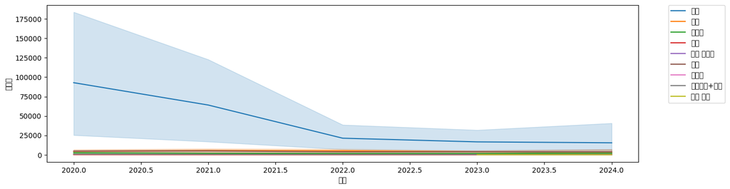

[output not shown]

[output cut: 53 more lines]

[output not shown]

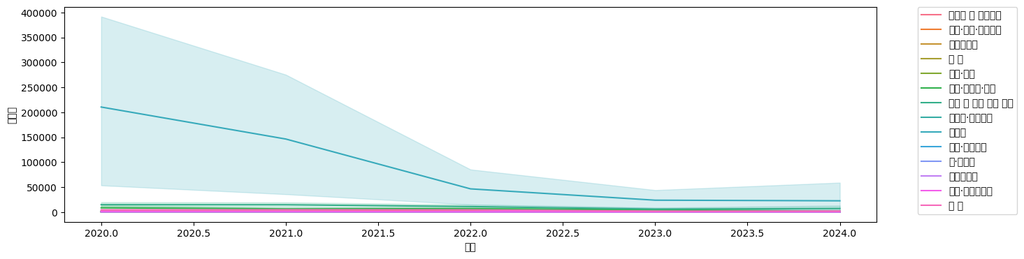

```python
plt.figure(figsize=(15,4))
sns.lineplot(data=df_tot, x='연도', y='백만원', hue='지역별(2)')
plt.legend(bbox_to_anchor=(1.05, 1), loc=2, borderaxespad=0)

plt.figure(figsize=(15,4))
sns.lineplot(data=df_tot, x='연도', y='백만원', hue='상품군별(1)')
plt.legend(bbox_to_anchor=(1.05, 1), loc=2, borderaxespad=0)
```

df_tot 데이터를 국가별, 상품군별로 나타낸 그래프이다.

20년부터 판매액이 전체적으로 감소하는 것을 볼 수 있다.